# Discussion Section Worksheet #2

Anupama Bhatta

September 12, 2023

# Learning objectives

- Make fundamental chart types in ggplot
- Modify graphical elements in a ggplot
- Practice knitting documents

# Visualization

This week, we will practice visualization in R. We will be using the ggplot library, as in Modern Dive Chapter 2 (the book will be very helpful!).

```r
library(ggplot2)
```

We'll practice with a dataset called `diamonds`. Let's inspect it using the `head()` function:

```r
head(diamonds)
```

```
## # A tibble: 6 × 10
##   carat cut       color clarity depth table price     x     y     z
##   <dbl> <ord>     <ord> <ord>   <dbl> <dbl> <int> <dbl> <dbl> <dbl>
## 1  0.23 Ideal     E     SI2      61.5    55   326  3.95  3.98  2.43
## 2  0.21 Premium   E     SI1      59.8    61   326  3.89  3.84  2.31
## 3  0.23 Good      E     VS1      56.9    65   327  4.05  4.07  2.31
## 4  0.29 Premium   I     VS2      62.4    58   334  4.2   4.23  2.63
## 5  0.31 Good      J     SI2      63.3    58   335  4.34  4.35  2.75
## 6  0.24 Very Good J     VVS2     62.8    57   336  3.94  3.96  2.48
```

This is a dataset about diamonds, as you might have guessed from the name. You can learn more about what the columns mean by pulling up the data documentation with `help()`, if you wish.

## Chart challenge

### 1. Scatterplot

Is there a relationship between carats and price? Make a scatterplot that helps us see the relationship. Make sure you think about which variable goes on which axis.

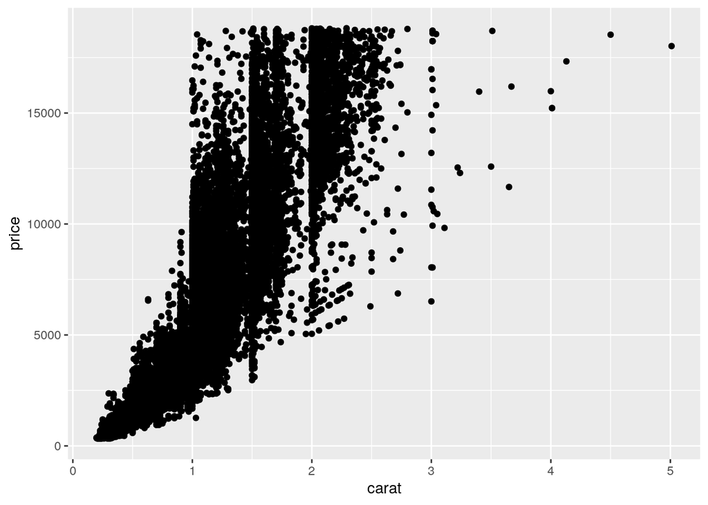

```r
ggplot(data = diamonds, aes(x = carat, y = price))+
  geom_point()
```

### 2. Histogram

What is the distribution of carats in the dataset? Make a histogram showing this distribution.

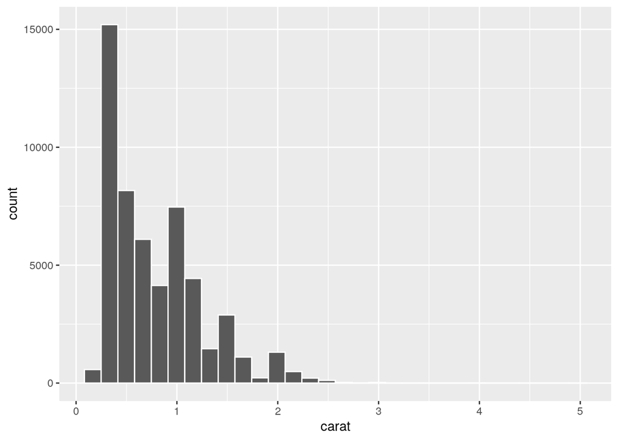

```r
ggplot(data = diamonds, aes (x = carat))+
  geom_histogram(bins = 30, color = "white")
```

### 3. Boxplots

What is the distribution of prices, split by cut? Notice that cut is a categorical variable, so we can use a boxplot for this visual.

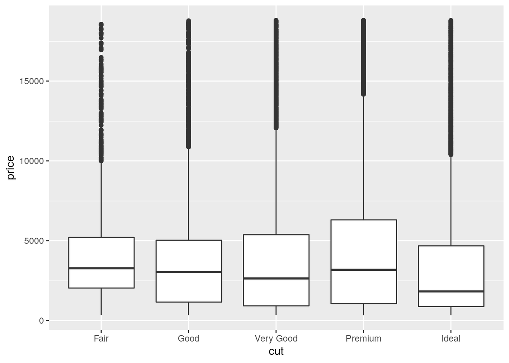

```r
ggplot(data = diamonds, aes(x = cut, y = price))+
  geom_boxplot()
```

### 4. Barplots

How many diamonds are there in each cut category? Make a barplot to show this.

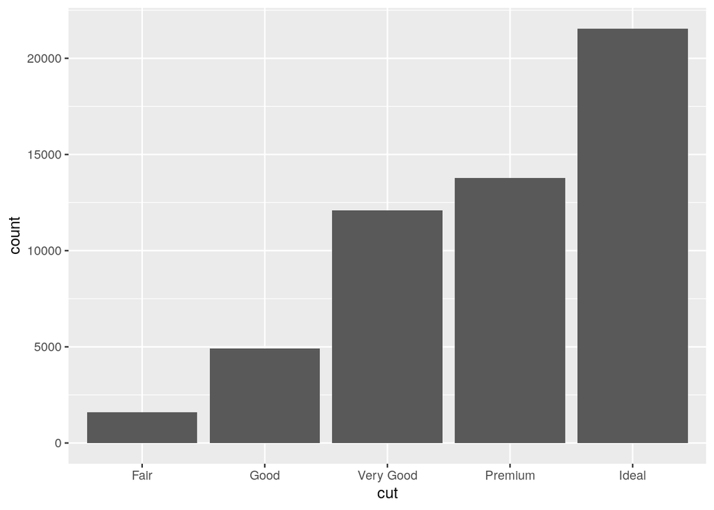

```r
ggplot(data = diamonds, aes(x = cut))+
  geom_bar()
```

### 5. Get fancy.

Choose one of your existing charts and modify a graphical element, such as color of your encodings.

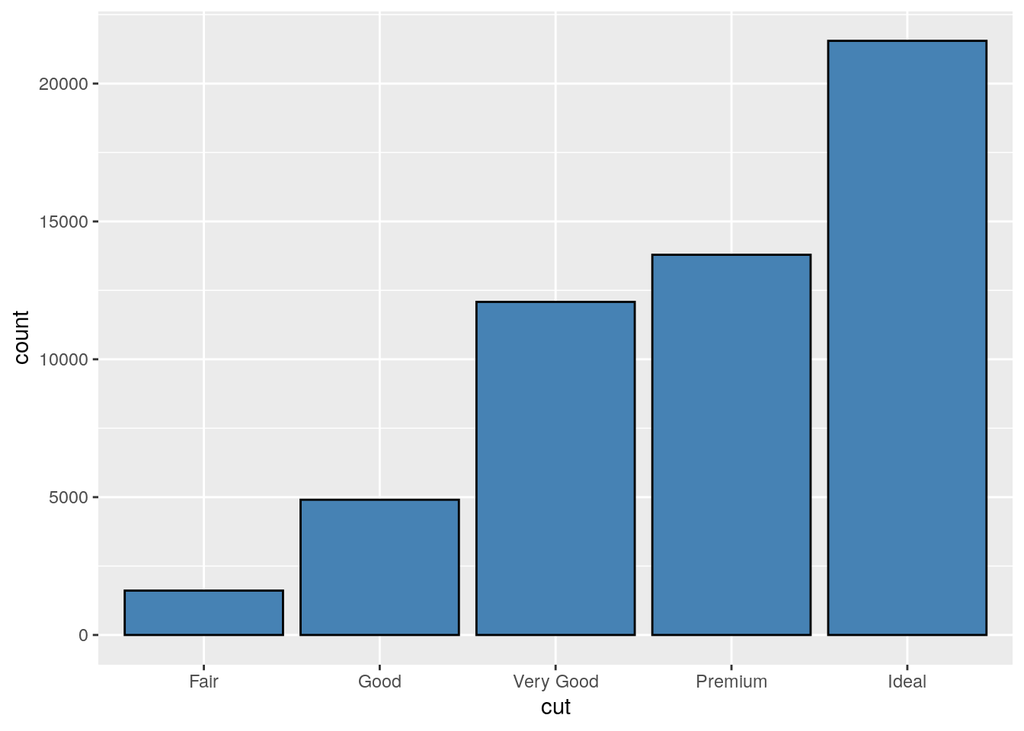

```r
ggplot(data = diamonds, aes(x = cut))+
  geom_bar(color = 'black', fill = 'steelblue')
```

### 6. Recreate this chart.

Write code that will replicate the chart in this week's discussion section folder (note that yours may not be exactly identical, as ggplots will display slightly differently on different size screens. We are looking for correct choice of chart type, aesthetics, and variables).

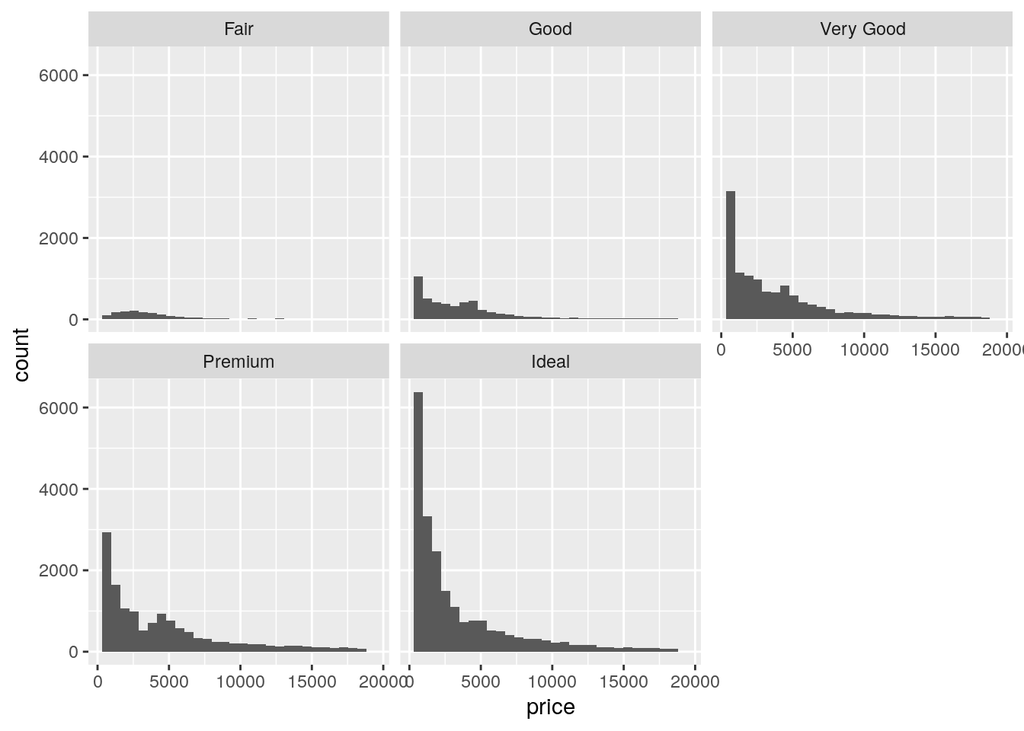

```r
ggplot(data = diamonds, aes(x = price))+
  geom_histogram()+
  facet_wrap(~cut, nrow =2)
```